# Min Heaps

Min Heaps are a data structure that can be used for many different purposes, and which are a particularly efficient mechanism for implementing priority queues.

## Binary Trees revisited

First, some binary tree terminology.

A *full* binary tree is such that every node has 0 or 2 children. It is not necessarily balanced or symmetric. For example:

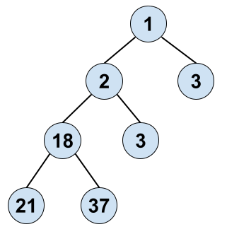

A *complete* binary tree is such that all levels are completely filled in, except the last level, which, if not completely filled in, is filled in left-to-right as far as possible. It is balanced and not necessarily symmetric. A complete binary tree is not necessarily *full*. For example:

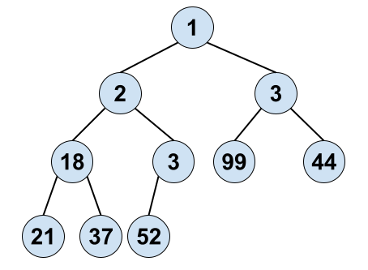

A *perfect* binary tree is a complete binary tree with all levels completely filled in. It is balanced and symmetric. A perfect binary tree is necessarily *full* and *complete*. For example:

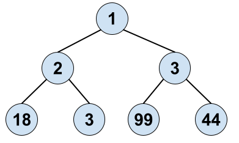

Remember: a binary search tree is designed for efficient retrieval of information. If there is no balance discipline applied to the tree, it could in the worst case provide only $O(n)$ searching, but if the tree is balanced (through the AVL or some other balancing algorithm), then searching it for any item is guaranteed to be be $O(log_2 n)$.

## Min heaps

Let's turn our attention now to a new kind of binary tree -- the *min heap*. There is also such a thing as a max heap, which is exactly a min heap with appropriate modifications. Min heaps and max heaps collectively are known as "binary heaps."

Note that in programming we often talk about "the heap" as a place in memory while data is stashed during running of programs (this will be a big topic in CS143); "the heap" is not a min heap or max heap and actually these kind of heaps have essentially no relationship. Just be aware that in talking about programming the word "heap" will crop up in different contexts with much different meanings.

A min heap has a constrained construction, like a BST, but less so. The requirement for a min heap is that every node is less than or equal to its two children (and this property is true at every node). For example:

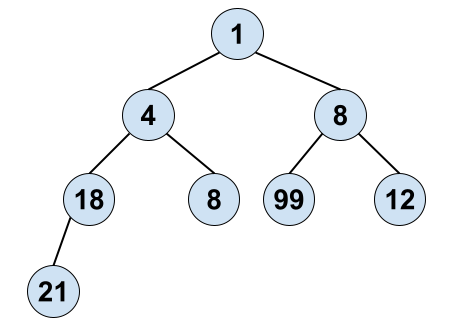

Note that it's perfectly OK to have duplicate items in a min heap, as shown here.

By convention, a min heap is a complete binary tree (as this one is), but it would be possible to satisfy the min heap constraint even in a non-complete binary tree.

Notice how, with a min heap, searching becomes a $O(n)$ operation in general. For example, if we wanted to check whether the heap above contains 512, we would have to check every element before concluding it is not contained in the heap. However, we do have *excellent* searching guaranteed for one task in particular: finding the smallest value in the heap! (i.e., min finding) That's immediate and thus $O(1)$.

So we have here a data structure that is great for exactly one specialized thing, and, otherwise, not so great.

## Inserting into a Min Heap

To insert a new value, fill in next slot in the complete binary tree shape. For example, adding 37 to the above heap would result in the following:

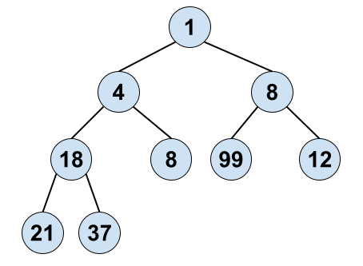

Notice how the min-heap property is still preserved (18 is still less than or equal to its two childen, 21 and 37).

But what if we add a value that perturbs the min-heap property? Let's say we add the value 2:

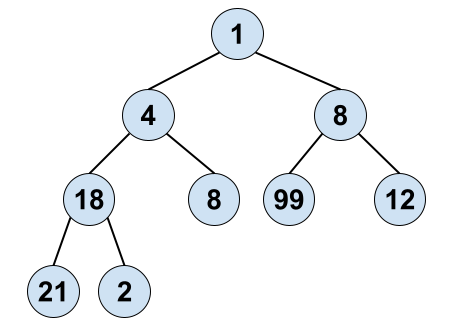

To restore the possibly-perturbed min-heap property, we need to *sift* the new value up until the min-heap property is restored (going as far as the root if necessary). In this case, we would first sift 2 up by swapping it with its parent.

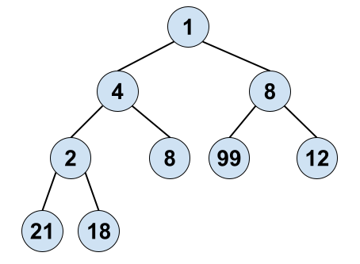

The heap-min property is restored for 2 (it is smaller than its two children), but it is still not being met in its parent node (4). So, we swap them as well:

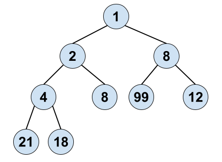

Now the min-heap property is restored for the entire heap. Notice how the sifting operation will take $O(log_2 n)$.

## Removing from a Min Heap

In a min-heap, we are only allowed to remove the minimum value (at the root). We do this by removing the root, and placing the the last-positioned item in the root. If we did this with the heap above, we would have the following:

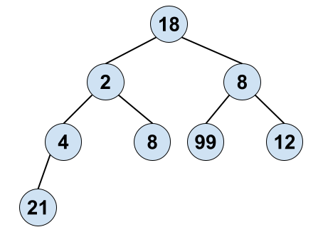

After doing this, the min-heap property is no longer met (the root is not smaller than its two children). The solution is to *sift down* as far as need. At each step, we choose the minimum of the offending node and its children, and swap the offending node with that minimum. Since the minimum of 18, 2, and 8 is 2, we swap 18 with 2:

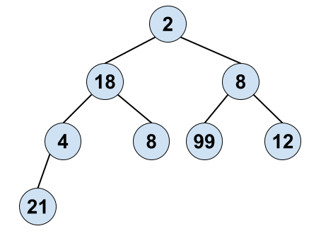

The min-heap property is not yet met (18 is not smaller than its children). Since the minimum of 18, 4, and 8 is 4, we swap 18 with 4:

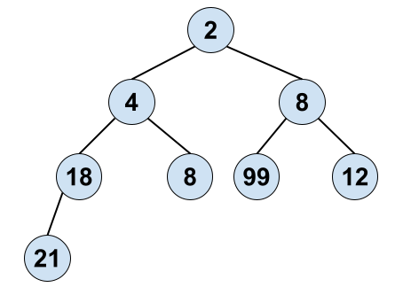

And now the min-heap property is restored.

## Min Heap Implementation

When we code up a min heap, we don't usually code up a binary tree in any of the ways we've done previously (expression trees, BSTs, AVL trees, Tries). Rather, we exploit the regular shape of the tree to represent the items of the tree side-by-side in an array (a contiguous block of memory, not often called "array" in Python but called by that name generally in programming).

We place each item in min heap in the array one level at a time. For example, the heap above would be represented as follows:

```python
heap = [2, 4, 8, 18, 8, 99, 12, 21]
```

Given the index `i` of any element in the heap, we can produce its parent and children with the following expressions:

- parent(`i`) is `(i - 1) // 2`
- left(`i`) is `2*i + 1`
- right(`i`) is `2*1 + 2`

Let's define some functions for this and informally check they behave as expected:

```python
def parent(i):
    return (i - 1) // 2

def left(i):
    return 2*i + 1

def right(i):
    return 2*i + 2
```

```python
print(f"The parent of {heap[7]} is {heap[parent(7)]}")
```

```
The parent of 21 is 18
```

```python
print(f"The left child of {heap[2]} is {heap[left(2)]}")
```

```
The left child of 8 is 99
```

```python
print(f"The right child of {heap[1]} is {heap[right(1)]}")
```

```
The right child of 4 is 8
```

Because we are able to represent the tree in an array, we are able to traverse the tree simply by hopping around the array according to these numerical relationships.

For heap insertion, we always fill in the next slot in the array, and then sift up by swapping items in the array logarithmically many times.

Similarly, for min removal, we swap the item from the last position in the tree into position 0, and then sift down by swapping items in the array logarithmically many times.

For a full implementation of a min heap, please see the provided `minheap.py` file, which contains a `MinHeap` class. We have also prepared tests for the min heap in file `test_minheap.py`.

## Priority Queue Revisited

Now that we have a min heap implementation, we can re-implement our priority queue to use it. Our code would look something like this:

```python
from minheap import MinHeap

class PriorityQueue:

    _mh: MinHeap

    def __init__(self):
        self._mh = MinHeap()

    def enqueue(self, value: str, priority: int) -> None:
        self._mh.insert(priority, value)

    def dequeue(self) -> tuple[str, int]:
        elem = self._mh.remove_min()
        assert elem is not None
        prio, val = elem

        return val, prio

    def update_priority(self, value: str, new_priority: int) -> None:
        self._mh.change_priority(value, new_priority)

    @property
    def size(self) -> int:
        return self._mh.size

    def __str__(self) -> str:
        return str(self._mh)
```

If we re-run the tests, we'll see that they all pass:

```
$ pytest -v test_pqueue.py
============================= test session starts ==============================
collected 10 items

test_pqueue.py::test_init PASSED                                         [ 10%]
test_pqueue.py::test_enqueue_single PASSED                               [ 20%]
test_pqueue.py::test_enqueue_repeated PASSED                             [ 30%]
test_pqueue.py::test_dequeue_single PASSED                               [ 40%]
test_pqueue.py::test_dequeue_multiple PASSED                             [ 50%]
test_pqueue.py::test_dequeue_repeated PASSED                             [ 60%]
test_pqueue.py::test_update_priority_single PASSED                       [ 70%]
test_pqueue.py::test_update_priority_multiple PASSED                     [ 80%]
test_pqueue.py::test_update_priority_nonexistent PASSED                  [ 90%]
test_pqueue.py::test_size PASSED                                         [100%]

============================== 10 passed in 0.01s ==============================
```

One reason we don't have to update the tests is because these tests were written based only on the *interface* of the `PriorityQueue` module so, when we changed its internal implementation (without changing its behaviour), our class still behaved as it did with our naive implementation.

These kind of tests are known as *black-box tests*. In the next set of notes, we will explore the difference between black-box testing and white-box testing.

## Heapsort - [Optional]

This data structure lends itself to an efficient sorting algorithm called Heapsort, which is as follows:

Given an array of ordered items (WLOG integers):

- construct a min heap by inserting items (including sifting up) as sketched above
- as long as the heap is not empty, remove and emit the min, repairing the heap with sifting down after each removal

Heapsort can be, and is often, done entirely in an array without any “tree programming” per se. Operationally, it’s just a series of array swaps, but the understanding of that array as a min heap, along with sift up and sift down operations, is the best way to guide the programmer to get it right.

Given $n$ items to sort, heapsort does $n$ insertions (each taking $O(\log n)$ time) to construct the heap and $n$ removals (each taking $O(\log n)$ time) to deconstruct it once constructed. It requires $O(n\cdot \log n)$ in the construction phase and $O(n\cdot \log n)$ in the deconstruction phase. In the world of algorithm analysis, this makes it an $O(n\cdot \log n)$ algorithm altogether (even though it's two $O(n\cdot \log n)$ processes in sequence -- we don't care that it's twice). For sorting, that's really fast! You'll learn all this in detail in algorithms; this is just a preview of that curriculum.

In conclusion, heapsort is a case of "trees in your head, arrays in your code" in that trees aren't directly present in your code, despite their critical presence conceptually.